# Nuodai kenkėjams

S15-2 (su sprendimu)

```r
# Paketai --------------------------------------------------------------------
library(conflicted)
library(tidyverse)

# Grafikams
library(ggpubr)

# Statistinei analizei
library(DescTools)
library(rstatix)
library(PMCMRplus)
library(effectsize)

# Nustatymai -----------------------------------------------------------------
knitr::opts_chunk$set(
  eval       = TRUE,
  fig.height = 3,
  fig.width  = 7,
  fig.align  = "center"
)

# Jei naudojate R ≥ 4.2.0, tai lokalės keisti nebūtina
# (t.y., su lokalės keitimu susijusias 5 eilutes galite ištrinti)
if (getRversion() < "4.2.0" && tolower(Sys.info()[['sysname']]) == "windows") {
  Sys.setlocale(locale = "Lithuanian")    # Windows ir R < 4.2.0
} else {
  Sys.setlocale(locale = "lt_LT.UTF-8")   # Linux, Mac arba R ≥ 4.2.0
}

ggplot2::theme_set(ggplot2::theme_bw())

# === Papildomos funkcijos ===================================================
# Jūsų projekte turi būti byla "funkcijos/sudaryk_cld.R"
source("funkcijos/sudaryk_cld.R", encoding = "UTF-8")
```

# 1 Užduotis

Atliktas eksperimentas, kurio metu kenkėjai nuodyti 3 medžiagomis ir stebėtas laikas (paromis) nuo medžiagos suvartojimo iki organizmo žūties. Visi organizmai gavo identišką nuodo koncentraciją. Kuo laikas trumpesnis, tuo nuodas efektyvesnis. Įvertinkite, kuris nuodas efektyviausias.

# 2 Duomenys

```r
readxl::excel_sheets("duomenys/kenkejai_nuodai.xlsx")
```

```
## [1] "duomenys"
```

```r
duomenys_xl <-
  readxl::read_excel("duomenys/kenkejai_nuodai.xlsx", sheet = "duomenys")
```

```r
glimpse(duomenys_xl)
```

```
## Rows: 48
## Columns: 2
## $ isgyvemino_laikas <dbl> 0.31, 0.45, 0.46, 0.43, 0.36, 0.29, 0.40, 0.23, 0.22…
## $ nuodas            <chr> "Dx5", "Dx5", "Dx5", "Dx5", "ToT", "ToT", "ToT", "To…
```

```r
duomenys <-
  duomenys_xl %>%
  rename(y = isgyvemino_laikas, grupe = nuodas) %>%
  # pasiverskim į kategorinį kintamąjį, kad veliau nekiltų problemų
  mutate(grupe = as_factor(grupe))
```

```r
head(duomenys)
```

| y | grupe |
| --- | --- |
| 0.31 | Dx5 |
| 0.45 | Dx5 |
| 0.46 | Dx5 |
| 0.43 | Dx5 |
| 0.36 | ToT |
| 0.29 | ToT |

```r
glimpse(duomenys)
```

```
## Rows: 48
## Columns: 2
## $ y     <dbl> 0.31, 0.45, 0.46, 0.43, 0.36, 0.29, 0.40, 0.23, 0.22, 0.21, 0.18…
## $ grupe <fct> Dx5, Dx5, Dx5, Dx5, ToT, ToT, ToT, ToT, LNX_8, LNX_8, LNX_8, LNX…
```

```r
duomenys %>% count(grupe)
```

| grupe | n |
| --- | --- |
| Dx5 | 16 |
| ToT | 16 |
| LNX_8 | 16 |

# 3 Suvestinės ir prielaidų tikrinimas

## 3.1 Duomenų suvestinės pagal klausimą

Aprašomoji statistika pogrupiams:

```r
Desc(y ~ grupe, data = duomenys, verbose = 3, plotit = FALSE)
```

```
## ------------------------------------------------------------------------------
## y ~ grupe (duomenys)
##
## Summary:
## n pairs: 48, valid: 48 (100.0%), missings: 0 (0.0%), groups: 3
##
##
##             Dx5      ToT    LNX_8
## mean      0.618    0.544    0.276
## median    0.625    0.420    0.270
## sd        0.209    0.289    0.062
## IQR       0.280    0.277    0.087
## n            16       16       16
## np      33.333%  33.333%  33.333%
## NAs           0        0        0
## 0s            0        0        0
## min       0.310    0.230    0.180
## max       1.100    1.240    0.380
## Q1        0.450    0.358    0.228
## Q3        0.730    0.635    0.315
## mad       0.259    0.178    0.067
## skew      0.567    1.074    0.246
## kurt     -0.543   -0.082   -1.383
##
## Kruskal-Wallis rank sum test:
##   Kruskal-Wallis chi-squared = 25.584, df = 2, p-value = 2.782e-06
```

Grafikai pogrupiams:

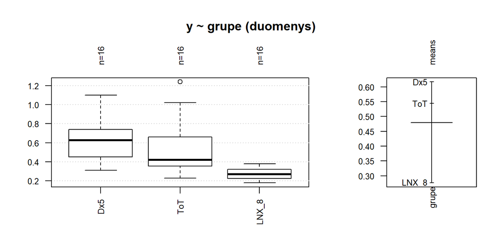

```r
par(las = 2) # Pasuka užrašus bazinės „R“ sistemos (bet ne ggplot2) grafikuose
plot(Desc(y ~ grupe, data = duomenys))
```

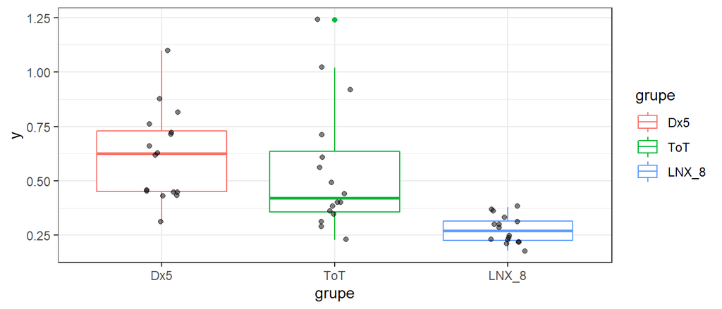

```r
duomenys %>%
  ggplot(aes(y = y, x = grupe, color = grupe)) +
  geom_boxplot() +
  geom_jitter(width = 0.1, color = "black", alpha = 0.5)
```

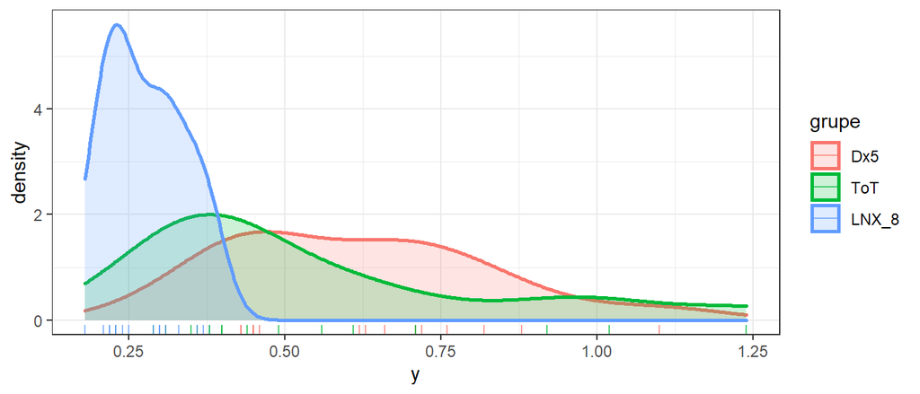

```r
duomenys %>%
  ggplot(aes(x = y, color = grupe, fill = grupe)) +
  geom_density(alpha = 0.2, lwd = 1, adjust = 1) +
  geom_rug(alpha = 0.7)
```

Iš aprašomosios statistikos panašu, kad skiriasi tiek grupių sklaida, tiek padėtis. Grupių dydžiai vienodi.

## 3.2 Prielaidų tikrinimas (pagal kintamuosius)

**Išskirčių paieška.** Didelės išskirtys gali iškreipti parametrinės analizės rezultatus. Tad vertinga patikrinti, ar kuriuos nors taškus galime laikyti išskirtimis.

```r
# Išskirčių paieška barjerų metodu.
duomenys %>% group_by(grupe) %>% identify_outliers(y)
```

| grupe | y | is.outlier | is.extreme |
| --- | --- | --- | --- |
| ToT | 1.24 | TRUE | FALSE |

Tikrųjų išskirčių nerasta.

**Normalumo vertinimas**

Pagal kintamuosius nusibraižome QQ diagramas ir taikome normalumo kriterijus (testus) kiekvienai grupei atskirai.

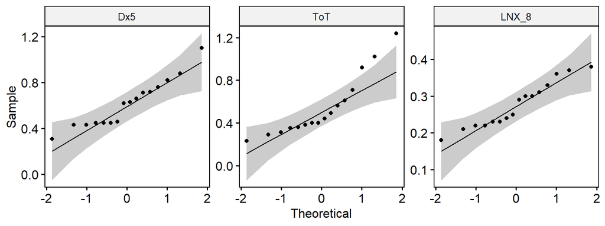

```r
duomenys %>% ggqqplot("y", facet.by = "grupe", scales = "free")
```

```r
duomenys %>% group_by(grupe) %>% shapiro_test(y)
```

| grupe | variable | statistic | p |
| --- | --- | --- | --- |
| Dx5 | y | 0.9323534 | 0.26558019 |
| ToT | y | 0.8525377 | 0.01485078 |
| LNX_8 | y | 0.9359595 | 0.30242810 |

Panašu, kad grupės `ToT` pasiskirstymas nukrypsta nuo normaliojo (nes šiai grupei būdinga dešinioji asimetrija, `skew = 1.07`). Laikykime, kad dėl to pažeidžiama normalumo prielaida.

**Lygių dispersijų prielaidos tikrinimas.**

Pažiūrime, kokios yra grupių dispersijos ir SD:

```r
# Dispersijų ir SD skaičiavimas bei santykis tarp didžiausios ir mažiausios reikšmių
duomenys %>%
  group_by(grupe) %>%
  summarise(dispersija = var(y), SD = sd(y)) %>%
  ungroup() %>%
  mutate(
    max_min_dispersiju_santykis = round(max(dispersija) / min(dispersija), 1),
    max_min_SD_santykis         = round(max(SD)         / min(SD),         1)
  )
```

| grupe | dispersija | SD | max_min_dispersiju_santykis | max_min_SD_santykis |
| --- | --- | --- | --- | --- |
| Dx5 | 0.043860000 | 0.20942779 | 21.6 | 4.6 |
| ToT | 0.083732917 | 0.28936641 | 21.6 | 4.6 |
| LNX_8 | 0.003878333 | 0.06227627 | 21.6 | 4.6 |

Dispersijos skiriasi apie 22 kartus.

Taikome statistinį Brown-Forsythe / Levene (centras - mediana) kriterijų:

```r
# DescTools::LeveneTest(y ~ grupe, data = duomenys)
rstatix::levene_test(y ~ grupe, data = duomenys)
```

| df1 | df2 | statistic | p |
| --- | --- | --- | --- |
| 2 | 45 | 4.196405 | 0.02132648 |

Lygių dispersijų prielaida aiškiai pažeista.

## 3.3 Pasirenkame analizės metodą

Dėl pažeistos normalumo prielaidos renkamės neparametrinį Kruskal-Walis kriterijų.

# 4 Pagrindinė analizė

## 4.1 **[C]** Kruskal-Wallis kriterijus

Prielaidos ir reikalavimai:

- tiriamieji tarpusavyje nepriklausomi,
- yra kelios nepriklausomos grupės.

Tinka, jei:

- netenkinama normalumo prielaida.

Kriterijus galingiausias, kai grupių duomenų *skirstiniai vienodos formos*: asimetrija vienodos krypties ir panašaus stiprumo, o sklaida – panašaus dydžio.

**Statistinis reikšmingumas.**

```r
kw_rez <- duomenys %>% kruskal_test(y ~ grupe)
kw_rez
```

|  | .y. | n | statistic | df | p | method |
| --- | --- | --- | --- | --- | --- | --- |
| 1 | y | 48 | 25.58437 | 2 | 2.78e-06 | Kruskal-Wallis |

```r
# X2 yra chi-kvadratu, dar kartais vadinama H statistika4
get_test_label(kw_rez, type = "text", detailed = TRUE)
```

```
## [1] "Kruskal-Wallis, X2(2) = 25.58, p = <0.0001, n = 48"
```

Skirtumas tarp skirtingų nuodų efektyvumų yra statistiškai reikšmingas (*p* < 0,001).

**Efekto dydis ($η^2_H$)**

Koeficientas $η^2_H$ yra neparametrinis η² (eta kvadratu) analogas, skaičiuojamas pagal Kruskal-Wallis kriterijaus rezultatus.

```r
duomenys %>% kruskal_effsize(y ~ grupe)
```

|  | .y. | n | effsize | method | magnitude |
| --- | --- | --- | --- | --- | --- |
| 1 | y | 48 | 0.5240972 | eta2[H] | large |

Efekto dydis $\eta^2_H = 0{,}52$ gali būti vertinamas kaip „didelis“.

# 5 *Post-hoc* (patikslinančioji) analizė

Jei pagrindinės analizės rezultatai buvo statistiškai **reikšmingi**, tada tęsiame analizę atlikdami porinius lyginimus (patikslinančiąją *post-hoc* analizę).

## 5.1 **[c]** *Post-hoc:* Conover-Iman kriterijus

**Conover-Iman** kriterijus yra neparametrinis ir tinkamas atlikti **Kruskal-Wallis** kriterijus *post-hoc* analizę (porinius palyginimus).

Statistinį reikšmingumą vertinti pagal `pval` (koreguotoji *p*).

```r
# Lyginimas: kiekviena grupė su kiekviena
# Paketas DescTools
conover_rez <- ConoverTest(y ~ grupe, data = duomenys, method = "holm")
conover_rez
```

```
##
##  Conover's test of multiple comparisons : holm
##
##           mean.rank.diff    pval
## ToT-Dx5         -6.78125  0.0530 .
## LNX_8-Dx5      -24.25000 2.1e-08 ***
## LNX_8-ToT      -17.46875 1.2e-05 ***
## ---
## Signif. codes:  0 '***' 0.001 '**' 0.01 '*' 0.05 '.' 0.1 ' ' 1
```

```r
# Jei reikia, kad rezultatai būtų pateikti duomenų lentele
conover_rez_df <-
  as.data.frame(conover_rez[[1]]) %>%
  rownames_to_column("groups") %>%
  separate("groups", into = c("group1", "group2"), sep = "-")

conover_rez_df
```

| group1 | group2 | mean rank diff | pval |
| --- | --- | --- | --- |
| ToT | Dx5 | -6.78125 | 5.302759e-02 |
| LNX_8 | Dx5 | -24.25000 | 2.131517e-08 |
| LNX_8 | ToT | -17.46875 | 1.238115e-05 |

**CLD.**

```r
# Funkcija užkrauta naudojant source()
# Pastaba: rezultatas bus neteisingas, jei grupių pavadinimuose yra „-“ ženklas
cld_rez_c <- sudaryk_cld(conover_rez, alpha = 0.05)
cld_rez_c
```

| group | cld | cld_sulygiuota |
| --- | --- | --- |
| ToT | a | a_ |
| LNX_8 | b | _b |
| Dx5 | a | a_ |

**Efekto dydis poroms.**

```r
# Neparametrinis r tipo efekto dydis, skaičiuotas pagal nepriklausomų imčių
# Mann-Whitney-Wilcoxon kriterijaus rezultatus
efekto_dydis_poroms_rw <-
  duomenys %>%
  wilcox_effsize(y ~ grupe) %>%
  arrange(desc(abs(effsize))) # Išrikiuoja eilutes pagal efekto dydį

efekto_dydis_poroms_rw
```

| .y. | group1 | group2 | effsize | n1 | n2 | magnitude |
| --- | --- | --- | --- | --- | --- | --- |
| y | Dx5 | LNX_8 | 0.8235010 | 16 | 16 | large |
| y | ToT | LNX_8 | 0.6602556 | 16 | 16 | large |
| y | Dx5 | ToT | 0.2800313 | 16 | 16 | small |

**Rezultatai grafiškai.**

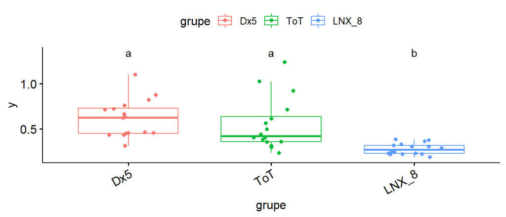

```r
# Aukštis y ašyje, ties kuriuo pateikta CLD etiketė grafike.
# Galite įrašyti konkretų skaičių:
y_koordinate <- max(duomenys$y) + diff(range(duomenys$y)) * 0.1

duomenys %>%
  ggboxplot(
    y     = "y",
    x     = "grupe",
    color = "grupe",
    add   = "jitter",
    ylim  = c(NA, y_koordinate)
  ) +
  rotate_x_text(angle = 30) +
  geom_text(aes(label = cld, x = group), y = y_koordinate, data = cld_rez_c)
```

# 6 Atsakymas

Tyrėme 3 nuodų (`Dx5`, `ToT` ir `LNX_8`, visais atvejais po 16 tiriamųjų) efektyvumą analizuodami organizmų išgyvenamą po poveikio gavus vienodą medžiagos dozę. Duomenis analizavome neparametrine Kruskal-Walis analize (reikšmingumo lygmuo α = 0,05), kuri atskleidė, kad skirtingų nuodų efektyvumas skiriasi ($χ²(2)$ = 25,58, $p$ < 0,001, $η^2_H$ = 0,52, $n$ = 48). Patikslinančioji Conover-Iman *post-hoc* analizė parodė, kad `LNX_8` nuodo poveikis nuo kitų dviejų skyrėsi statistiškai reikšmingai (lentelė 1), šios grupės išgyvenamumo laiko medianos įvertis buvo mažiausias (grupių `Dx5`, `ToT` ir `LNX_8` medianos yra atitinkamai 0,63, 0,42 ir 0,27 paros), todėl galime teigti, kad nuodas `LNX_8` yra efektyviausias.

```r
#
conover_rez_df %>%
  # Suapvalinamos p reikšmės
  mutate(p_adj = scales::pvalue(pval, decimal.mark = ",")) %>%
  select(-`mean rank diff`, -pval) %>%
  rename("Nuodas 1" = group1, "Nuodas 2" = group2, "p (koreguotoji)" = p_adj) %>%
  knitr::kable(
    caption = "Lentelė 1.
    Conover-Iman analizės (porinių palyginimų) rezultatai.
    P reikšmės koreguotos Holm metodu.
    Reikšmingumo lygmuo – 0,05."
  )
```

Lentelė 1. Conover-Iman analizės (porinių palyginimų) rezultatai. P reikšmės koreguotos Holm metodu. Reikšmingumo lygmuo – 0,05.

| Nuodas 1 | Nuodas 2 | p (koreguotoji) |
| --- | --- | --- |
| ToT | Dx5 | 0,053 |
| LNX_8 | Dx5 | <0,001 |
| LNX_8 | ToT | <0,001 |

Žymėjimai: $n$ – imties dydis, $η^2_H$ efekto dydis Kruskal-Wallis analizei (kitimo ribos nuo 0 iki 1), $p$ reikšmė.

**Pastaba:** rezultatų aprašyme rekomenduočiau pateikti ir tvarkingai apipavidalintą grafiką.